# Spatial Ecology Gila Monsters in a Resource Subsidized Environment

M. Pierson

Overview of the spatial ecology of Gila Monsters (*Heloderma suspectum*) at Stone Canyon Golf Club as a resource subsidized population vs. Owl Head Buttes representing the unsubsized natural population. Compared home range sizes of *Heloderma suspectum* between two populations. One represented a subsidized population at Stone Canyon Golf Club and the other at Owl Head Buttes representing the unsubsidized population. Stone Canyon is located in Oro Valley on the north end of Tucson, Arizona. Owl Head Buttes is located about 17 km straight line distance north west from Stone Canyon. Data at Owl Head was collected from 2000 - 2002, while fixes were collected from 2007 - 2013 at Stone Canyon. We Calculated minimum convex polygons using both 95 percent and 100 percent of the locations for each lizard, as well as 95% and 50% Kernel Density Estimations (KDE).

[output not shown]

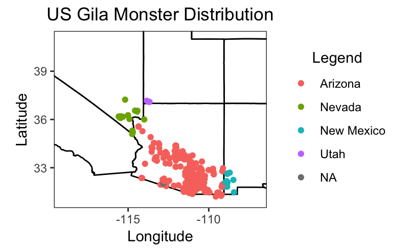

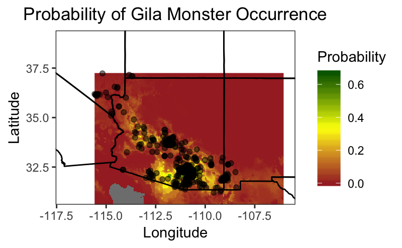

Summary of home range size.

Table 1 | Pooled overall home ranges of Gila Monsters at Owl Head Buttes and Stone Canyon Golf Club. Both 100% and 95% MCPs were calculated between both populations.

```
Table: Home range sizes of Stone Canyon and Owl head Buttes using both 95 percent and 100 percent MCPs.

Year   Gila   Sex      Environment      Home_Range_100mcp   N100   Home_Range_95mcp   N95
-----  -----  -------  --------------  ------------------  -----  -----------------  ----
2000   1      female   nonsubsidized                25.20     42              23.00    38
_      2      male     nonsubsidized                28.70    125              24.50   112
_      3      male     nonsubsidized                82.70     89              68.40    78
_      4      male     nonsubsidized                55.60     80              40.50    73
2001   1      female   nonsubsidized                20.10     26                 NA    NA
_      2      male     nonsubsidized                23.50     10                 NA    NA
_      3      male     nonsubsidized                60.10     18                 NA    NA
_      4      male     nonsubsidized                24.40     21                 NA    NA
_      10     male     nonsubsidized                28.50     14                 NA    NA
_      11     male     nonsubsidized                10.60     22                 NA    NA
_      12     male     nonsubsidized                23.60      7                 NA    NA
_      13     female   nonsubsidized                 8.90      9                 NA    NA
_      15     female   nonsubsidized                13.00     11                 NA    NA
_      50     female   nonsubsidized                21.00     11                 NA    NA
_      51     female   nonsubsidized                 7.10      8                 NA    NA
2002   2      male     nonsubsidized                66.20     38              40.00    37
_      4      male     nonsubsidized                73.10     76              55.50    73
_      10     male     nonsubsidized                39.50    111              33.30   105
_      11     male     nonsubsidized                39.30     92              31.90    88
_      12     male     nonsubsidized                49.50     66              41.50    63
_      13     female   nonsubsidized                26.30    101              23.70    96
_      15     female   nonsubsidized                39.20     98              21.30    94
_      17     female   nonsubsidized                47.60    106              29.10   101
_      50     female   nonsubsidized                15.80     68              14.10    66
_      51     female   nonsubsidized                18.50     57              12.40    57
2007   F104   female   subsidized                    3.37     18               3.37    19
_      F114   female   subsidized                    2.51      8               0.58     7
_      F36    female   subsidized                    5.05     20               3.49    19
_      F66    female   subsidized                   10.23     22               5.56    20
_      M112   male     subsidized                   12.51     13              12.51    12
_      M14    male     subsidized                    4.66     15               3.87    14
2008   F104   female   subsidized                    4.97     53               3.47    50
_      F114   female   subsidized                   11.96     52               9.38    49
_      F135   female   subsidized                    4.07     16               1.58    15
_      F137   female   subsidized                    5.98     15               5.75    14
_      F36    female   subsidized                    9.73     54               7.55    51
```

[output cut: 31 more lines]

```
_      M14    male     subsidized                    4.48     13               3.84    12
_      M215   male     subsidized                   11.47     16              11.47    15
_      M255   male     subsidized                    5.85     16               5.59    15
2012   F114   female   subsidized                   10.17     54               7.15    51
_      F137   female   subsidized                    2.06     13               1.36    12
_      F147   female   subsidized                   17.64     52              16.75    49
_      F252   female   subsidized                    5.19     53               3.63    50
_      F36    female   subsidized                   10.34     52              10.30    49
_      M14    male     subsidized                    4.42     13               3.77    12
_      M215   male     subsidized                   11.04     21               9.85    20
_      M255   male     subsidized                    8.21     13               5.39    12
2013   F114   female   subsidized                    1.16      7               0.28     6
_      F147   female   subsidized                    0.31      6               0.00     5
_      F252   female   subsidized                      NA      4                 NA    NA
_      F36    female   subsidized                    0.13      6               0.00     5
```

Gila Monster Home Range Sizes at Stone Canyon vs. Owl Head Buttes.

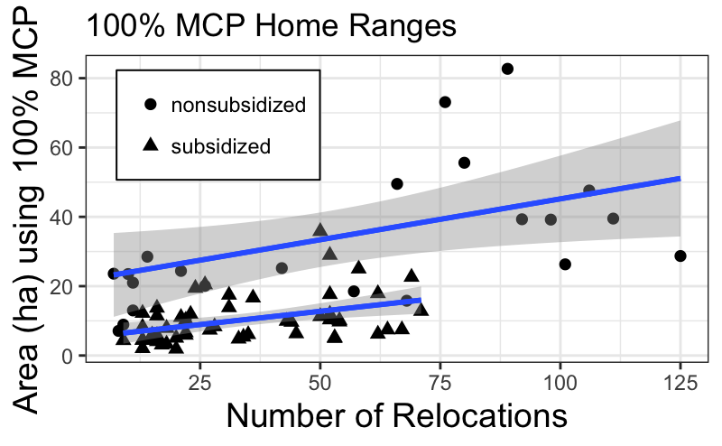

Figure 1 | Non-Subsidized (Owl Head Buttes) vs. Subsidized (Stone Canyon) population 100% MCPs by number of fixes across the whole study interval.

Table 2 | Group 100% MCP home range means of raw data of Stone Canyon and Owl Head Buttes. Grouped by environment and sex.

```
Table: Group Means of Overall Home Ranges at Stone Canyon and Owl Head Buttes

Environment     Sex        N   Home_Range_100mcp          sd         se          ci
--------------  -------  ---  ------------------  ----------  ---------  ----------
nonsubsidized   female    11           22.063636   12.287414   3.704795    8.254797
nonsubsidized   male      14           43.235714   21.672372   5.792185   12.513255
subsidized      female    37            9.836757    6.984007   1.148164    2.328584
subsidized      male      16           11.707500    6.907877   1.726969    3.680948
```

Table 3 | Group 95% MCP home range means of raw data of Stone Canyon and Owl Head Buttes. Grouped by environment and sex.

```
Table: Group Means of Overall 95% MCP Home Ranges at Stone Canyon and Owl Head Buttes

Environment     Sex        N   Home_Range_95mcp          sd          se          ci
--------------  -------  ---  -----------------  ----------  ----------  ----------
nonsubsidized   female     6          20.600000    6.286493   2.5664502    6.597270
nonsubsidized   male       8          41.950000   13.987954   4.9454886   11.694222
subsidized      female    37           7.132432    4.339651   0.7134342    1.446912
subsidized      male      16           9.067500    5.094327   1.2735817    2.714575
```

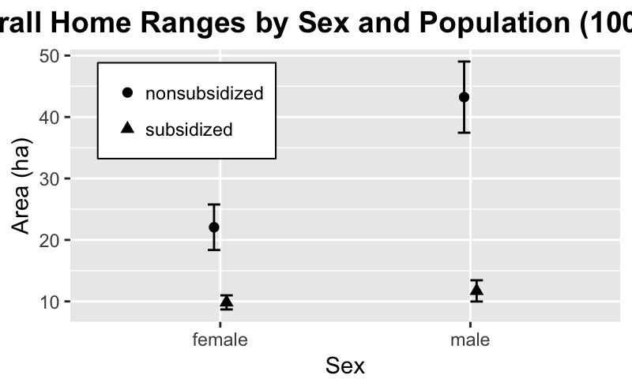

Figure 3 | Raw overall mean home ranges between environment and sex. Note, that before adjusted home ranges, males exhibit smaller overall home ranges at Stone Canyon, than males of Owl Head Buttes.

Gila Monster Yearly Home Range Shifts of 100% MCPs.

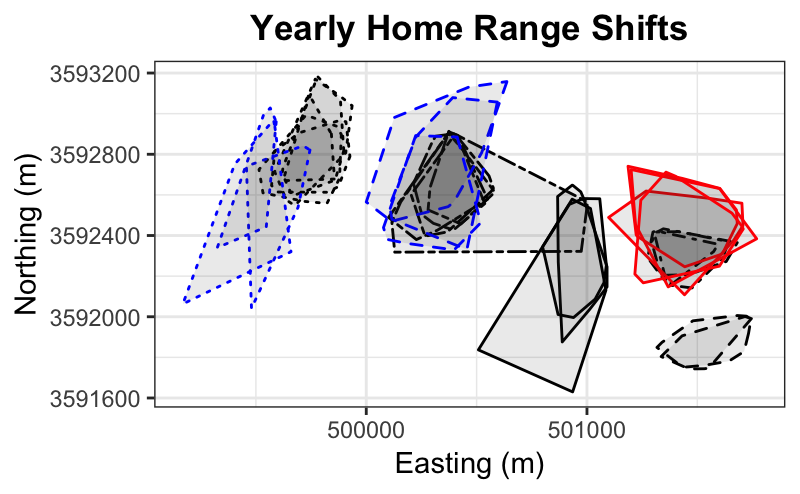

Figure 4 | Yearly home range shifts of sub-sampled home ranges of 8 lizards, both males and females. Home range shifts appear to be relativley stable over study years.

Repeated measures ANOVA for Yearly Home Ranges by Sex.

Repeated Measure ANOVA for 100% MCP overall home ranges

```
Linear mixed model fit by REML. t-tests use Satterthwaite's method ['lmerModLmerTest']
Formula: Home_Range_100mcp ~ Environment + Year + Sex + N100 + Environment *
    Sex + (1 | Gila)
   Data: year

REML criterion at convergence: 573.4

Scaled residuals:
     Min       1Q   Median       3Q      Max
-2.75980 -0.39242 -0.05151  0.28203  3.07570

Random effects:
 Groups   Name        Variance Std.Dev.
 Gila     (Intercept) 29.62    5.443
 Residual             82.78    9.098
Number of obs: 79, groups:  Gila, 30

Fixed effects:
                                Estimate Std. Error         df t value Pr(>|t|)
(Intercept)                   -1.072e+03  1.679e+03  7.165e+01  -0.638 0.525333
Environmentsubsidized         -1.542e+01  8.207e+00  6.638e+01  -1.880 0.064559 .
Year                           5.419e-01  8.389e-01  7.165e+01   0.646 0.520346
Sexmale                        1.967e+01  4.862e+00  2.518e+01   4.046 0.000435 ***
N100                           1.917e-01  4.144e-02  5.484e+01   4.625 2.33e-05 ***
Environmentsubsidized:Sexmale -1.484e+01  6.081e+00  2.719e+01  -2.441 0.021450 *
---
Signif. codes:  0 ‘***’ 0.001 ‘**’ 0.01 ‘*’ 0.05 ‘.’ 0.1 ‘ ’ 1

Correlation of Fixed Effects:
            (Intr) Envrnm Year   Sexmal N100
Envrnmntsbs  0.855
Year        -1.000 -0.856
Sexmale     -0.043  0.278  0.041
N100         0.060  0.121 -0.062 -0.041
Envrnmnts:S  0.012 -0.332 -0.011 -0.801  0.101
```

ANOVA Table: 100% MCP

```
Type III Analysis of Variance Table with Satterthwaite's method
                 Sum Sq Mean Sq NumDF  DenDF F value    Pr(>F)
Environment      719.49  719.49     1 71.576  8.6920 0.0043136 **
Year              34.54   34.54     1 71.651  0.4173 0.5203462
Sex             1351.82 1351.82     1 26.188 16.3309 0.0004154 ***
N100            1770.69 1770.69     1 54.843 21.3913 2.325e-05 ***
Environment:Sex  493.10  493.10     1 27.186  5.9570 0.0214502 *
---
Signif. codes:  0 ‘***’ 0.001 ‘**’ 0.01 ‘*’ 0.05 ‘.’ 0.1 ‘ ’ 1
```

Repeated Measure ANOVA for 95% MCP overall home ranges

```
Linear mixed model fit by REML. t-tests use Satterthwaite's method ['lmerModLmerTest']
Formula: Home_Range_95mcp ~ Environment + Year + Sex + N100 + Environment *
    Sex + (1 | Gila)
   Data: year

REML criterion at convergence: 416.1

Scaled residuals:
    Min      1Q  Median      3Q     Max
-2.5866 -0.3142 -0.0239  0.2939  2.1056

Random effects:
 Groups   Name        Variance Std.Dev.
 Gila     (Intercept) 42.58    6.525
 Residual             14.24    3.774
Number of obs: 68, groups:  Gila, 30

Fixed effects:
                                Estimate Std. Error         df t value Pr(>|t|)
(Intercept)                   -868.75075  808.91445   39.02219  -1.074 0.289432
Environmentsubsidized          -17.87976    5.09289   57.98897  -3.511 0.000872 ***
Year                             0.44337    0.40411   39.02461   1.097 0.279296
Sexmale                         21.82943    4.31027   25.65769   5.065 2.94e-05 ***
N100                             0.02367    0.03032   40.40428   0.781 0.439569
Environmentsubsidized:Sexmale  -16.25133    4.97477   32.87969  -3.267 0.002548 **
---
Signif. codes:  0 ‘***’ 0.001 ‘**’ 0.01 ‘*’ 0.05 ‘.’ 0.1 ‘ ’ 1

Correlation of Fixed Effects:
            (Intr) Envrnm Year   Sexmal N100
Envrnmntsbs  0.643
Year        -1.000 -0.647
Sexmale     -0.035  0.396  0.033
N100        -0.006  0.276  0.003 -0.051
Envrnmnts:S -0.002 -0.460  0.004 -0.865  0.044
```

ANOVA Table: 95% MCP

```
Type III Analysis of Variance Table with Satterthwaite's method
                Sum Sq Mean Sq NumDF  DenDF F value   Pr(>F)
Environment     470.59  470.59     1 61.980 33.0376 2.96e-07 ***
Year             17.15   17.15     1 39.025  1.2038 0.279296
Sex             430.74  430.74     1 32.267 30.2402 4.53e-06 ***
N100              8.68    8.68     1 40.404  0.6094 0.439569
Environment:Sex 152.01  152.01     1 32.880 10.6717 0.002548 **
---
Signif. codes:  0 ‘***’ 0.001 ‘**’ 0.01 ‘*’ 0.05 ‘.’ 0.1 ‘ ’ 1
```

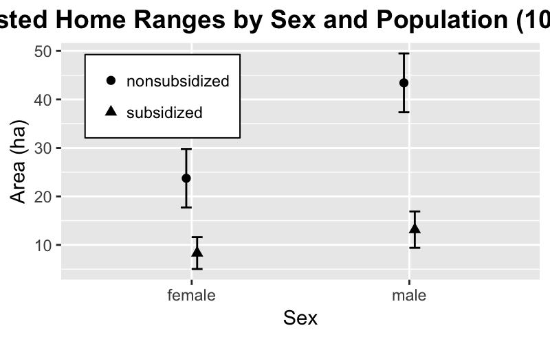

Figure 5 | Adjusted home ranges between sexes of non-subsidized and subsidized populations. Adjusted for environment, year, sex, and sample size.

Table 3. Directional means of home range after being adjusted for year, sex and sample size.

```
Table: Adjusted Group Means of Overall Home Ranges at Stone Canyon and Owl Head Buttes

Environment     Sex          lsmean         SE         df    lower.CL   upper.CL
--------------  -------  ----------  ---------  ---------  ----------  ---------
nonsubsidized   female    23.739759   6.015077   66.85165   11.733125   35.74639
subsidized      female     8.314934   3.281775   46.24553    1.710009   14.91986
nonsubsidized   male      43.412310   6.061028   66.27236   31.312006   55.51261
subsidized      male      13.146356   3.754579   53.70952    5.617946   20.67477
```

Post-Hoc comparisons between sexes and environment:

```
$emmeans
Environment = nonsubsidized:
 Sex    emmean   SE   df lower.CL upper.CL
 female  23.74 6.02 66.8    11.73     35.7
 male    43.41 6.06 66.3    31.31     55.5

Environment = subsidized:
 Sex    emmean   SE   df lower.CL upper.CL
 female   8.31 3.28 46.2     1.71     14.9
 male    13.15 3.75 53.7     5.62     20.7

Degrees-of-freedom method: kenward-roger
Confidence level used: 0.95

$contrasts
Environment = nonsubsidized:
 contrast      estimate   SE   df t.ratio p.value
 female - male   -19.67 4.87 31.6 -4.041  0.0003

Environment = subsidized:
 contrast      estimate   SE   df t.ratio p.value
 female - male    -4.83 3.71 36.4 -1.301  0.2014
```

Graphical Comparisons of Sex Within Each Environment:

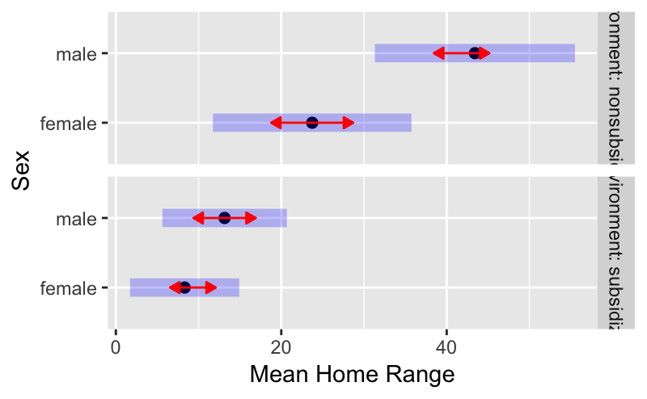

Figure 6 | Pairwise comparisons of home range between sexes within each environment. If red arrows overlap those of others, then there is no significant statistical difference.

```
$emmeans
Sex = female:
 Environment   emmean   SE   df lower.CL upper.CL
 nonsubsidized  23.74 6.02 66.8    11.73     35.7
 subsidized      8.31 3.28 46.2     1.71     14.9

Sex = male:
 Environment   emmean   SE   df lower.CL upper.CL
 nonsubsidized  43.41 6.06 66.3    31.31     55.5
 subsidized     13.15 3.75 53.7     5.62     20.7

Degrees-of-freedom method: kenward-roger
Confidence level used: 0.95

$contrasts
Sex = female:
 contrast                   estimate   SE   df t.ratio p.value
 nonsubsidized - subsidized     15.4 8.36 68.3 1.845   0.0694

Sex = male:
 contrast                   estimate   SE   df t.ratio p.value
 nonsubsidized - subsidized     30.3 8.60 69.4 3.517   0.0008
```

Graphical Comparisons of Sex between the two populations:

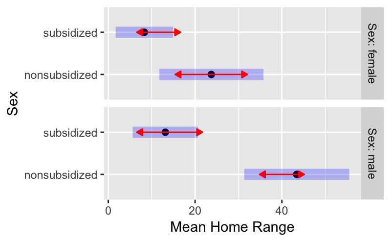

Figure 7 | Paiwise comparisons of sex between environments. If red arrows overlap those of others, then there is no significant statistical difference.

Seasonal Home Range.

Scaling home range analyses by seasonal estimates reduces the number or locations for each lizard. 100% MCPs were used for seasonal home range analyses to avoid any further reduction of locations for each estimation.

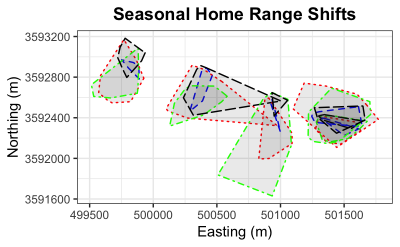

Figure 8 | Seasonal home range shifts of four lizards. Emergence and post-monsoon ranges stay realatively within each other. All seasonal polygons stay relatively stable without any major shifts away from other seasonal ranges.

Table 5 | Group means of seasonal home ranges between Stone Canyon (subsidized) and Owl Head Buttes (non-subsidized). These means are averaged across sex.

```r
seasonal<-read.csv("SC_Seasonal_Data.csv")
library(Rmisc)
SEAS_GRP_Means <- summarySE(seasonal, measurevar="Home_Range_100mcp", groupvars=c("Environment","Season"), na.rm = TRUE)
# SEAS_GRP_Means
kable(SEAS_GRP_Means, format = "pandoc", caption = 'Raw Group Means of Seasonal Home Ranges at Stone Canyon')
```

```
Table: Raw Group Means of Seasonal Home Ranges at Stone Canyon

Environment     Season           N   Home_Range_100mcp          sd          se         ci
--------------  -------------  ---  ------------------  ----------  ----------  ---------
nonsubsidized   Dry             12          23.7166667   12.841682   3.7070742   8.159215
nonsubsidized   Emergence       10           2.8100000    3.121414   0.9870776   2.232925
nonsubsidized   Monsoon         13          23.6538462    9.446482   2.6199828   5.708452
nonsubsidized   Post_Monsoon    11           0.6909091    1.013365   0.3055411   0.680788
subsidized      Dry             17          13.0364706   10.574940   2.5647997   5.437133
subsidized      Emergence        9           2.0977778    1.649566   0.5498555   1.267969
subsidized      Monsoon         18          10.5600000    7.518662   1.7721657   3.738943
subsidized      Post_Monsoon    14           2.9885714    5.044404   1.3481737   2.912552
```

RMANOVA on Seasonal Home Ranges:

```
Linear mixed model fit by REML. t-tests use Satterthwaite's method ['lmerModLmerTest']
Formula: Home_Range_100mcp ~ Environment + Season + Sex + N + Environment *
    Season + (1 | Gila)
   Data: seasonal

REML criterion at convergence: 638.5

Scaled residuals:
    Min      1Q  Median      3Q     Max
-2.0273 -0.5931 -0.0665  0.2579  3.2815

Random effects:
 Groups   Name        Variance Std.Dev.
 Gila     (Intercept)  4.442   2.108
 Residual             44.819   6.695
Number of obs: 100, groups:  Gila, 30

Fixed effects:
                                          Estimate Std. Error        df t value Pr(>|t|)
(Intercept)                               14.61312    2.89899  78.80446   5.041 2.89e-06
Environmentsubsidized                     -6.62866    2.80355  88.30266  -2.364  0.02025
SeasonEmergence                          -15.53191    3.06290  69.30082  -5.071 3.16e-06
SeasonMonsoon                              2.99228    2.88291  67.22814   1.038  0.30302
SeasonPost_Monsoon                       -16.49965    3.21222  78.88963  -5.137 1.97e-06
Sexmale                                    2.64121    1.69487  29.11504   1.558  0.12995
N                                          0.10913    0.03989  72.75357   2.735  0.00782
Environmentsubsidized:SeasonEmergence      7.62510    4.16148  75.14358   1.832  0.07087
Environmentsubsidized:SeasonMonsoon       -6.17899    3.69021  67.26127  -1.674  0.09869
Environmentsubsidized:SeasonPost_Monsoon   9.36224    3.88337  68.51543   2.411  0.01860

(Intercept)                              ***
Environmentsubsidized                    *
SeasonEmergence                          ***
SeasonMonsoon
SeasonPost_Monsoon                       ***
Sexmale
N                                        **
Environmentsubsidized:SeasonEmergence    .
Environmentsubsidized:SeasonMonsoon      .
Environmentsubsidized:SeasonPost_Monsoon *
---
Signif. codes:  0 ‘***’ 0.001 ‘**’ 0.01 ‘*’ 0.05 ‘.’ 0.1 ‘ ’ 1

Correlation of Fixed Effects:
            (Intr) Envrnm SsnEmr SsnMns SsnP_M Sexmal N      Env:SE Env:SM
Envrnmntsbs -0.629
SeasnEmrgnc -0.621  0.527
SeasonMonsn -0.581  0.562  0.524
SsnPst_Mnsn -0.677  0.504  0.525  0.514
Sexmale     -0.447  0.079  0.060  0.021  0.071
N           -0.581  0.003  0.193  0.065  0.341  0.313
Envrnmnt:SE  0.281 -0.614 -0.678 -0.366 -0.284  0.054  0.159
Envrnmnt:SM  0.499 -0.696 -0.423 -0.786 -0.425 -0.051 -0.121  0.448
Envrnm:SP_M  0.386 -0.654 -0.381 -0.407 -0.735  0.072 -0.005  0.443  0.501
```

```
Type III Analysis of Variance Table with Satterthwaite's method
                    Sum Sq Mean Sq NumDF  DenDF F value    Pr(>F)
Environment         261.63  261.63     1 26.365  5.8375 0.0229042 *
Season             2072.56  690.85     3 78.967 15.4143 5.534e-08 ***
Sex                 108.84  108.84     1 29.115  2.4285 0.1299532
N                   335.38  335.38     1 72.754  7.4829 0.0078202 **
Environment:Season  920.94  306.98     3 71.524  6.8493 0.0004028 ***
---
Signif. codes:  0 ‘***’ 0.001 ‘**’ 0.01 ‘*’ 0.05 ‘.’ 0.1 ‘ ’ 1
```

Table 6 | Seasonal home range means between Stone Canyon (subsidized) and Owl Head Buttes (non-subsidized) popuations for males and females. These are raw means before being adjusted for environment, season, sex, and sample size.

```
Table: Seasonal Means by Sex Between Populations

Environment     Season         Sex        N   Home_Range_100mcp           sd          se           ci
--------------  -------------  -------  ---  ------------------  -----------  ----------  -----------
nonsubsidized   Dry            female     5          15.6600000    8.6291946   3.8590932   10.7145603
nonsubsidized   Dry            male       7          29.4714286   12.6476235   4.7803524   11.6971008
nonsubsidized   Emergence      female     5           4.4600000    3.4333657   1.5354478    4.2630866
nonsubsidized   Emergence      male       5           1.1600000    1.8242807   0.8158431    2.2651436
nonsubsidized   Monsoon        female     6          22.9833333    9.8151753   4.0070285   10.3003948
nonsubsidized   Monsoon        male       7          24.2285714    9.8668999   3.7293376    9.1253605
nonsubsidized   Post_Monsoon   female     4           1.4000000    1.4491377   0.7245688    2.3059014
nonsubsidized   Post_Monsoon   male       7           0.2857143    0.3670993   0.1387505    0.3395102
subsidized      Dry            female    11          10.1754545    8.0883118   2.4387178    5.4338018
subsidized      Dry            male       6          18.2816667   13.2661214   5.4158714   13.9219406
subsidized      Emergence      female     6           2.1133333    1.8474920   0.7542354    1.9388239
subsidized      Emergence      male       3           2.0666667    1.5326556   0.8848792    3.8073277
subsidized      Monsoon        female    11          10.6918182    8.4988679   2.5625051    5.7096172
subsidized      Monsoon        male       7          10.3528571    6.3010018   2.3815548    5.8274547
subsidized      Post_Monsoon   female    11           3.6309091    5.5527983   1.6742317    3.7304207
subsidized      Post_Monsoon   male       3           0.6333333    0.8007705   0.4623250    1.9892241
```

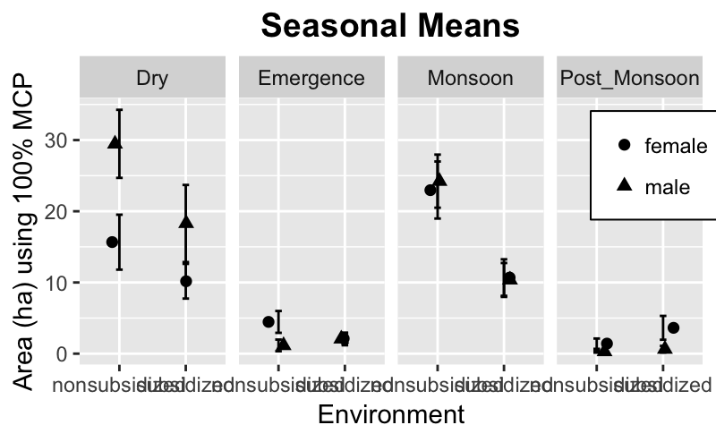

Figure 9 | Raw seasonal means of sexes between each environment. *WORKING GRAPH…

Adjusted Seasonal Means

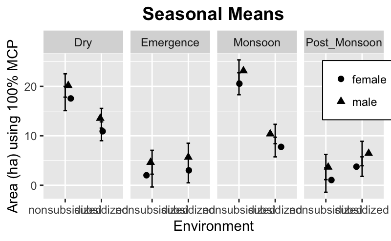

Figure 10 | Adjusted seasonal home range means of sexes between environments. *WORKING GRAPH…

Post-Hoc comparisons between populations for seasonal home range analysis:

```
$emmeans
Season = Dry:
 Environment   emmean   SE   df lower.CL upper.CL
 nonsubsidized  18.86 2.25 88.4   14.383    23.34
 subsidized     12.23 1.75 87.4    8.745    15.72

Season = Emergence:
 Environment   emmean   SE   df lower.CL upper.CL
 nonsubsidized   3.33 2.24 88.7   -1.118     7.77
 subsidized      4.32 2.55 84.7   -0.741     9.39

Season = Monsoon:
 Environment   emmean   SE   df lower.CL upper.CL
 nonsubsidized  21.85 2.03 87.5   17.811    25.89
 subsidized      9.04 1.78 86.0    5.515    12.57

Season = Post_Monsoon:
 Environment   emmean   SE   df lower.CL upper.CL
 nonsubsidized   2.36 2.36 87.0   -2.322     7.04
 subsidized      5.09 2.07 85.8    0.981     9.21

Results are averaged over the levels of: Sex
Degrees-of-freedom method: kenward-roger
Confidence level used: 0.95

$contrasts
Season = Dry:
 contrast                   estimate   SE   df t.ratio p.value
 nonsubsidized - subsidized    6.629 2.81 88.3  2.358  0.0206

Season = Emergence:
 contrast                   estimate   SE   df t.ratio p.value
 nonsubsidized - subsidized   -0.996 3.32 87.7 -0.300  0.7648

Season = Monsoon:
 contrast                   estimate   SE   df t.ratio p.value
 nonsubsidized - subsidized   12.808 2.66 87.2  4.814  <.0001

Season = Post_Monsoon:
 contrast                   estimate   SE   df t.ratio p.value
 nonsubsidized - subsidized   -2.734 2.96 89.4 -0.924  0.3581

Results are averaged over the levels of: Sex
```

Graphical Comparisons of seasons between the two populatins:

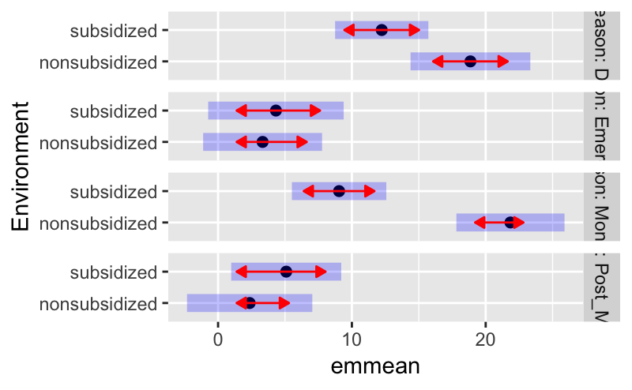

Figure 11 | Pairwise comparisons of each season between environments. Overlapping red bars indicate no statistical difference.

```
$emmeans
Environment = nonsubsidized:
 Season       emmean   SE   df lower.CL upper.CL
 Dry           18.86 2.25 88.4   14.383    23.34
 Emergence      3.33 2.24 88.7   -1.118     7.77
 Monsoon       21.85 2.03 87.5   17.811    25.89
 Post_Monsoon   2.36 2.36 87.0   -2.322     7.04

Environment = subsidized:
 Season       emmean   SE   df lower.CL upper.CL
 Dry           12.23 1.75 87.4    8.745    15.72
 Emergence      4.32 2.55 84.7   -0.741     9.39
 Monsoon        9.04 1.78 86.0    5.515    12.57
 Post_Monsoon   5.09 2.07 85.8    0.981     9.21

Results are averaged over the levels of: Sex
Degrees-of-freedom method: kenward-roger
Confidence level used: 0.95

$contrasts
Environment = nonsubsidized:
 contrast                 estimate   SE   df t.ratio p.value
 Dry - Emergence            15.532 3.07 69.4  5.054  <.0001
 Dry - Monsoon              -2.992 2.89 67.3 -1.036  0.7292
 Dry - Post_Monsoon         16.500 3.24 78.9  5.098  <.0001
 Emergence - Monsoon       -18.524 2.91 68.0 -6.361  <.0001
 Emergence - Post_Monsoon    0.968 3.08 73.0  0.314  0.9891
 Monsoon - Post_Monsoon     19.492 3.03 74.0  6.426  <.0001

Environment = subsidized:
 contrast                 estimate   SE   df t.ratio p.value
 Dry - Emergence             7.907 3.11 88.6  2.543  0.0602
 Dry - Monsoon               3.187 2.28 66.0  1.395  0.5070
 Dry - Post_Monsoon          7.137 2.68 80.2  2.666  0.0450
 Emergence - Monsoon        -4.720 3.20 89.6 -1.475  0.4569
 Emergence - Post_Monsoon   -0.769 2.94 77.2 -0.262  0.9937
 Monsoon - Post_Monsoon      3.951 2.78 84.9  1.421  0.4899

Results are averaged over the levels of: Sex
P value adjustment: tukey method for comparing a family of 4 estimates
```

Graphical Comparisons between seasons within the two populations:

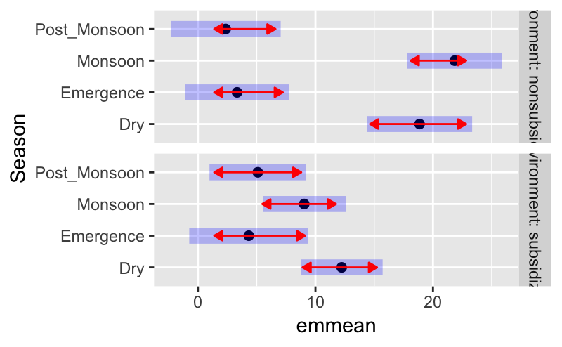

Figure 12 | Pairwise comparisons between seasons within each environment. Overlapping red bars indicate no statistical difference.

Pairwise seasonal comparisons between sexes of the subsidized population

```
$emmeans
Season = Dry:
 Sex    emmean   SE   df lower.CL upper.CL
 female   6.92 2.19 47.2    2.523     11.3
 male    20.36 2.77 48.3   14.798     25.9

Season = Emergence:
 Sex    emmean   SE   df lower.CL upper.CL
 female   5.00 2.91 45.2   -0.853     10.9
 male     5.63 4.00 49.0   -2.403     13.7

Season = Monsoon:
 Sex    emmean   SE   df lower.CL upper.CL
 female   6.27 2.34 46.2    1.560     11.0
 male    11.39 2.51 48.4    6.354     16.4

Season = Post_Monsoon:
 Sex    emmean   SE   df lower.CL upper.CL
 female   5.94 2.09 47.9    1.738     10.1
 male     3.09 3.99 48.5   -4.937     11.1

Degrees-of-freedom method: kenward-roger
Confidence level used: 0.95

$contrasts
Season = Dry:
 contrast      estimate   SE   df t.ratio p.value
 female - male  -13.441 3.68 47.2 -3.653  0.0006

Season = Emergence:
 contrast      estimate   SE   df t.ratio p.value
 female - male   -0.632 4.73 49.0 -0.134  0.8943

Season = Monsoon:
 contrast      estimate   SE   df t.ratio p.value
 female - male   -5.121 3.53 47.1 -1.449  0.1539

Season = Post_Monsoon:
 contrast      estimate   SE   df t.ratio p.value
 female - male    2.847 4.36 48.9  0.652  0.5173
```

Graphical Comparisons between sex within the subsidized population:

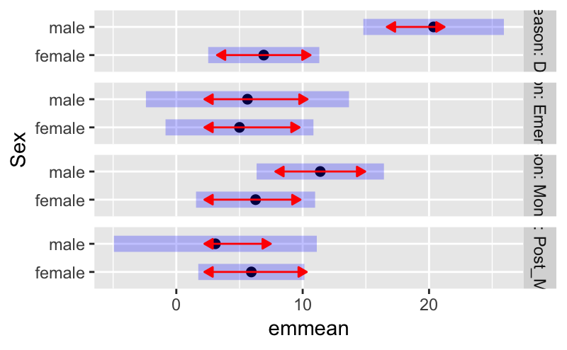

Table 7 | Mean individual seasoanl home ranges pooled from the entire study period. Missing values are depicted where no locations for that animal during that period were successfull.

```
Table: Seasonal Individual Home Ranges.

X        Emergence   X.1         X.2     Dry     X.3     Monsoon   X.4      Post.Monsoon   X.5
-------  ----------  ----------  ------  ------  ------  --------  -------  -------------  ------
Lizard   Sex         Area (ha)   N       Area    N       Area      N        Area           N
M69      Male        0.33        4.00    36.73   24.00   14.84     22.00    0.07           8.00
M67      Male        NA          NA      5.71    9.00    7.72      7.00     NA             NA
M255     Male        3.23        7.00    NA      NA      1.07      9.00     NA             NA
M215     Male        2.64        7.00    8.28    11.00   7.22      12.00    NA             NA
M14      Male        NA          NA      6.20    15.00   7.50      10.00    NA             NA
M119     Male        NA          NA      27.84   17.00   19.98     67.00    1.55           9.00
M112     Male        NA          NA      24.93   16.00   14.14     29.00    0.28           8.00
F66      Female      0.33        5.00    9.60    97.00   33.65     79.00    1.36           16.00
F36      Female      2.94        12.00   24.99   99.00   10.30     118.00   19.14          27.00
F252     Female      1.27        8.00    2.54    14.00   6.48      30.00    0.39           9.00
F214     Female      NA          NA      5.04    10.00   7.79      28.00    1.87           9.00
F200     Female      NA          NA      4.71    8.00    4.23      40.00    2.05           12.00
F147     Female      5.44        14.00   25.52   57.00   18.21     70.00    7.14           18.00
F146     Female      NA          NA      9.55    22.00   5.97      17.00    0.03           7.00
F137     Female      1.71        6.00    6.54    43.00   6.95      62.00    2.19           17.00
F135     Female      NA          N       3.71    25.00   5.72      48.00    0.68           5.00
F114     Female      0.99        12.00   13.66   99.00   10.72     84.00    4.56           24.00
F104     Female      NA          NA      6.07    70.00   7.59      49.00    0.53           13.00

Means    Overall     1.89                13.04           10.56              2.99
         Male        2.07                18.28           10.35              0.63
         Female      2.11                10.18           10.69              3.63
```

Gila Monster Home Range Overlap of 100% MCPs.

[interactive chart not shown]

Figure 13 | Interactive map: Home Range overlap by sex of 100% MCPs at Stone Canyon. Red polygons represent female lizards, and blue represents male lizards.

[interactive chart not shown]

Figure 14 | Interactive map: Home Range overlap by sex of 95% KDEs at Stone Canyon. Red polygons represent female lizards, and blue represents male lizards.

Table 8 | Home range overlap of Gila Monsters at the nutrient subsidized site. Male-male overlaps only occured between two pairs of males: M14-M69 and M119-M215 at 0.5 ha. and 19.5 ha. respectively and were therefore not included in the table.

```
Table: Home range overlap of Stone Canyon Gila Monsters using 100% MCPs.

ID              F36          F66    F104   F135   F137   F146   F147   X             M14           M67    M69    M112    M119    M215    M255
--------------  -----------  -----  -----  -----  -----  -----  -----  ------------  ------------  -----  -----  ------  ------  ------  -----
Female:Female                                                          Male:Female
F36             _            5.13   _      _      _      4.65   _                    _             _      _      _       19.44   18.51   _
F66             5.13         _      _      _      _      5.05   _                    _             _      2.6    _       _       _       _
F104            _            _      _      0.5           _      _                    _             _      _      _       _       _       _
F114            _            _      _      _      _      _      _                    _             _      _      5.82    _       _       _
F135            _            _      0.5    _      2.89   _      3.94                 _             _      2.04   _       _       _       _
F137            _            _      _      2.89   _      _      7.91                 _             _      0.55   _       _       _       _
F146            4.65         5.05   _      _      _      _      _                    0.14          _      0.76   _       _       _       _
F147            _            _      _      3.94   7.91   _      _                    3.73          0.21   4.6    _       _       _       _
F200            _            _      _      _      _      _      _                    _             _      _      6.49    _       _       _
F252            _            _      _      _      _      _      _                    _             _      _      _       _       _       3.45

Mean =          4.3 ± 0.86                                             Mean =        5.26 ± 1.78


ID              F36          F66    F104   F135   F137   F146   F147                 M14           M67    M69    M112    M119    M215    M255
Female:Female                                                          Male:Female
Net             6.84         7.25   0.5    4.44   7.91   6.77   8.96                 3.87          0.21   8.57   12.31   21.24   20.32   3.45
Prportion       0.2          0.2    0.1    0.5    1      0.7    0.3                  0.4           0.02   0.5    0.4     0.6     1       0.2
```